# PD4

Bogdan Jastrzębski

17 - 04 - 2019

# 1 Wstęp

W niniejszej pracy zbadamy działanie algorytmu SVM z jądrem gausowskim. Omówimy wpływ normalizacji danych, a także wpływ parametrów.

Będziemy używać zbiorów “wine_quality” i “apartments”.

# 2 Pierwsze dopasowanie i opis parametrów

SVM to właściwie klasa algorytmów machine-learningowych, które łączy podejście “widest street”. SVM pozwala na podmianę kerneli, przez co modele SVM de facto ostatecznie działają bardzo różnie. W tej pracy zajęliśmy się kernelem gausowskim, którego funkcja kernelowa przedstawia się w następujący sposób:

$$k(x,y) = e^{-\gamma ||x-y||^2}, \gamma>0$$

gdzie $\gamma$ jest parametrem. W bardzo dużym uproszczeniu można przyjąć, że $\gamma$ to parametr złożoności - im większa, tym model jest bardziej “complex”.

Oto wyniki wstępnej klasyfikacji na zbiorze apartments wraz z porównaniem z randomForest:

| Miara | SVM | RandomForest |
| --- | --- | --- |
| mse | 833341.9559287 | 89991.6855904 |
| rmse | 912.8756520 | 299.9861423 |
| mae | 704.2683224 | 225.9161006 |
| rsq | 0.0217060 | 0.8910439 |

na zbiorze wine_quality:

| Miara | SVM | RandomForest |
| --- | --- | --- |
| mse | 0.4855166 | 0.3389284 |
| rmse | 0.6967902 | 0.5821756 |
| mae | 0.5193204 | 0.4282097 |
| rsq | 0.2572526 | 0.4773139 |

Jak widać wyniki random forest są znacząco lepsze w obydwu przypadkach.

Spróbujemy przebić RandomForest normalizując dane, a także dostosowując prawidłowo parametr $\gamma$.

# 3 Normalizacja

Wg. tego opracowania: http://pyml.sourceforge.net/doc/howto.pdf, normalizacja danych ma znaczenie dla SVM. Znormalizujmy dane i zobaczmy, czy to prawda.

Apartments:

| Miara | SVM | SVM po normalizacji |
| --- | --- | --- |
| mse | 833341.9559287 | 786986.3018805 |
| rmse | 912.8756520 | 887.1224841 |
| mae | 704.2683224 | 681.6014224 |
| rsq | 0.0217060 | 0.0410073 |

Wine_quality:

| Miara | SVM | SVM po normalizacji |
| --- | --- | --- |
| mse | 0.4855166 | 0.3918088 |
| rmse | 0.6967902 | 0.6259463 |
| mae | 0.5193204 | 0.4598560 |
| rsq | 0.2572526 | 0.3963673 |

# 4 Tuning parametu $\gamma$

Metodą random search spróbujemy znaleźć dobry parametr $\gamma$.

Zaproponowane parametry dla zbiorów apartments i wine_quality to kolejno gamma=0.0451 i gamma=0.204, a wyniki przedstawiają się następująco:

Apartments:

| Miara | SVM | SVM po normalizacji i tuningu |
| --- | --- | --- |
| mse | 833341.9559287 | 26424.6979436 |
| rmse | 912.8756520 | 162.5567530 |
| mae | 704.2683224 | 126.9778145 |
| rsq | 0.0217060 | 0.9669210 |

Wine_quality:

| Miara | SVM | SVM po normalizacji i tuningu |
| --- | --- | --- |
| mse | 0.4855166 | 0.3865521 |
| rmse | 0.6967902 | 0.6217332 |
| mae | 0.5193204 | 0.4508506 |
| rsq | 0.2572526 | 0.4049754 |

Zmiany są, by nie przebierać w słowach, dramatyczne, choć przy wine_quality nie udało się pobić randomForest.

# 5 Dalex: Explain!

A teraz pokażemy jak utworzone wyżej modele zachowują się od wewnątrz.

Na początku zbiór Apartments:

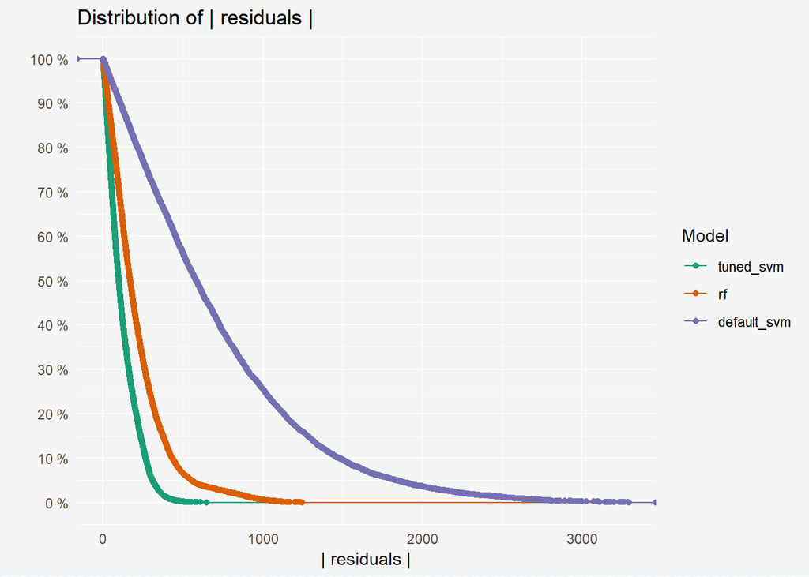

```r
load("plots3.rda")
plot_ap_perfor
```

Oto jak przedstawia się wykres rezyduów. Nasz tuned_svm ma znakomitą dokładność.

Przyjrzyjmy się najważniejszym zmiennym:

Surface:

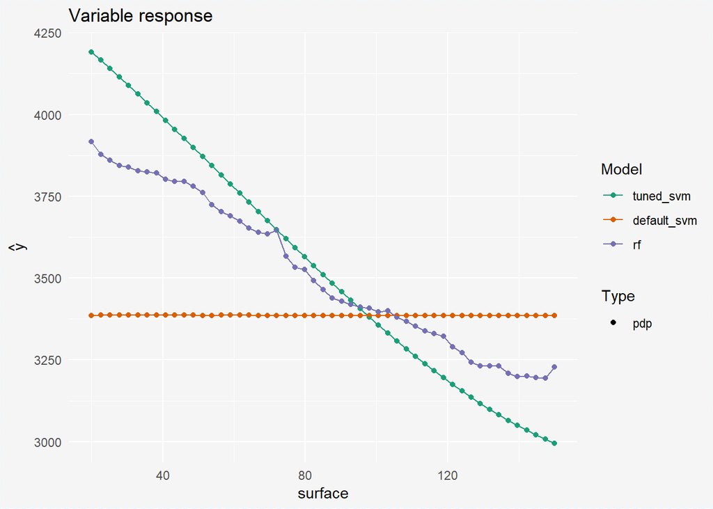

```r
load("plots.rda")
plot_surface
```

Floor:

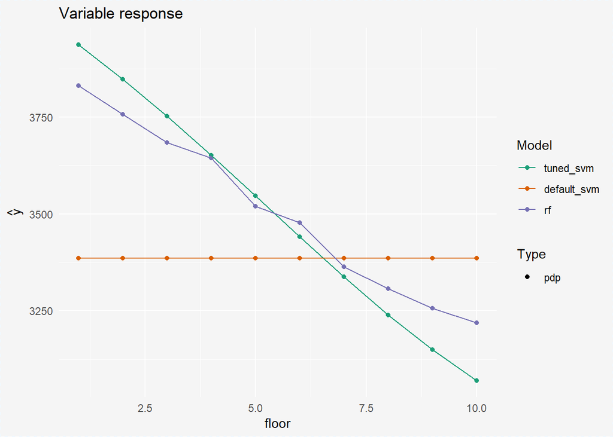

```r
plot_floor
```

Taka sama sytuacja jak wyżej.

Counstruction year

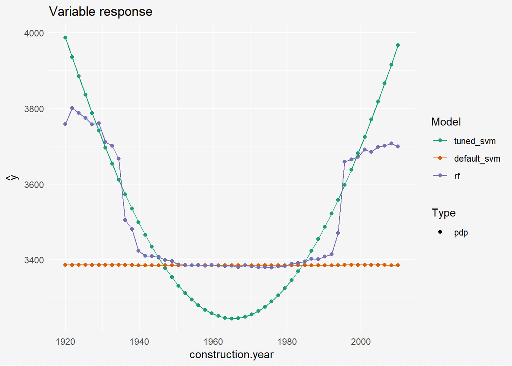

```r
plot_con.year
```

Właśnie na tym wykresie dobrze widać, że nastawione $\gamma$ pozwala na umiarkowaną złożoność. Tutaj lepszym dopasowaniem jest krzywa podobna do randomForest, jednak tuned_svm proponuje zależność kwadratową. Okazuje się, że jest wystarczająca.

Number of rooms:

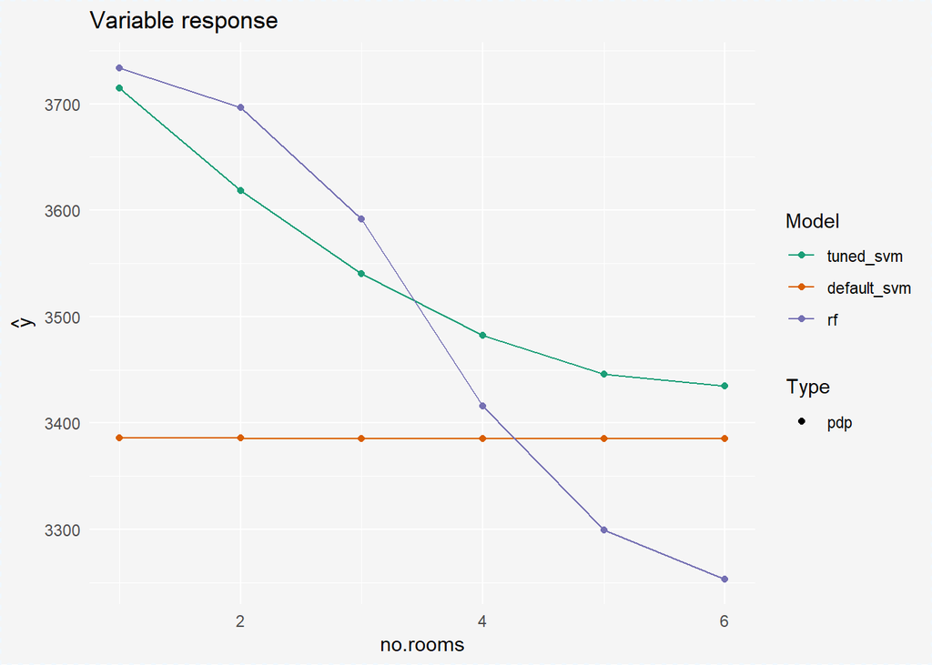

```r
plot_no.rooms
```

Tutaj ponownie, default_svm nie wyłapał zależności, tuned zaproponował kwadratową, a randomForest jeszcze inną.

A teraz wine_quality:

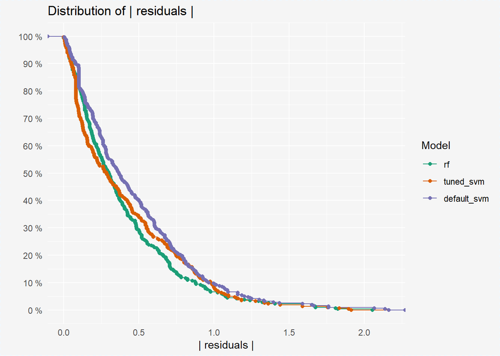

```r
plot_ab_perfor
```

Tu ponownie tuned_svm dobry, jednak nie lepszy od randomForest.

Najważniejsze zmienne:

Alcohol:

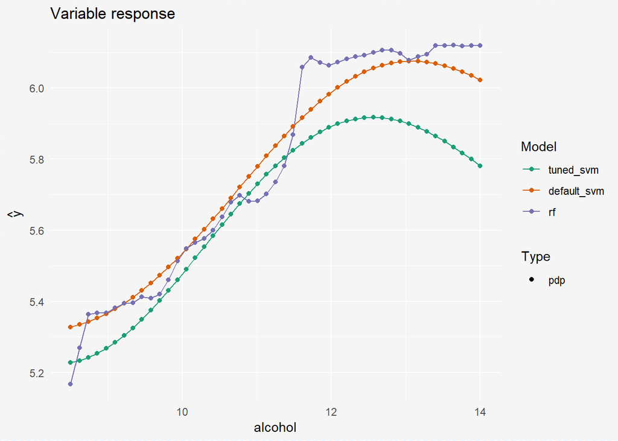

```r
load("plots_wine.rda")
plot_alcohol
```

RandomForest bardzo nieregularny, tuned i default podobnie złożone.

Sulphates

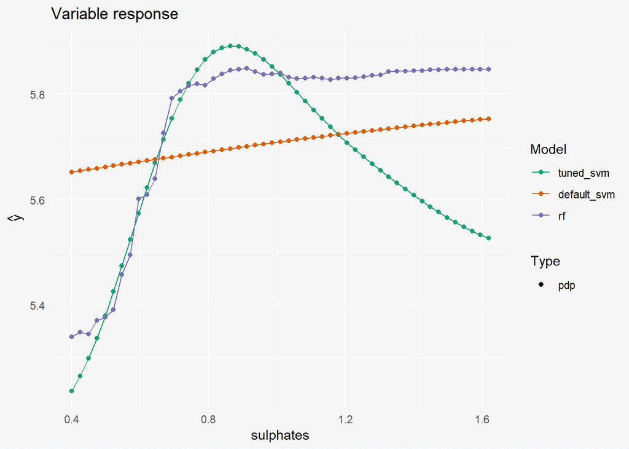

```r
plot_sulphates
```

Tutaj widać działanie dostosowania parametru. Krzywa tuned_svm i randomForest zbliżone.

Total sulfur dioxide:

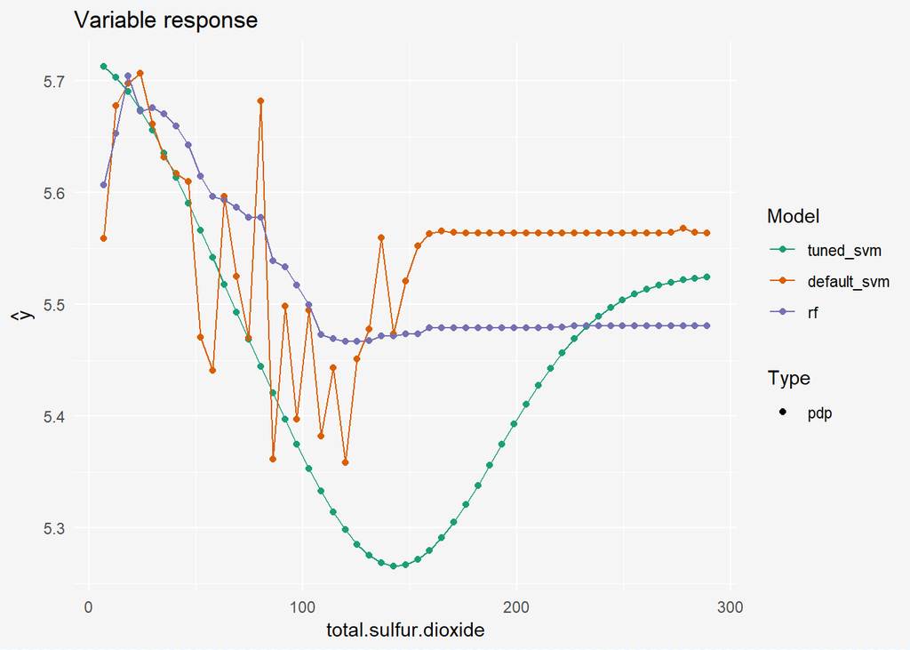

```r
plot_total.sulfur.dioxide
```

Tym razem podstawowy svm charakteryzuje się dużą zmiennością, podczas gdy tuned i randomForest umiarkowaną.

Volatile acidity:

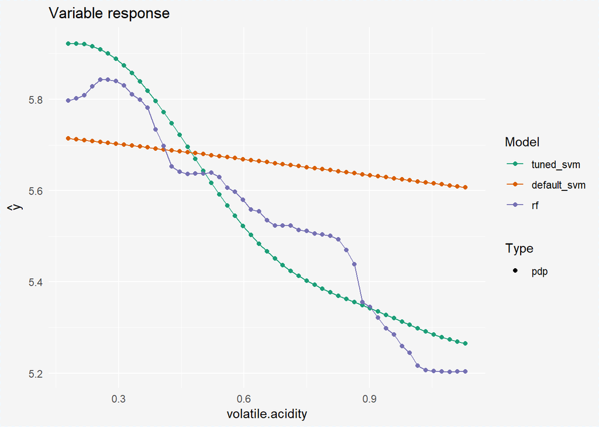

```r
plot_volatile.acidity
```

Podobnie jak zmienne wyżej.

pH:

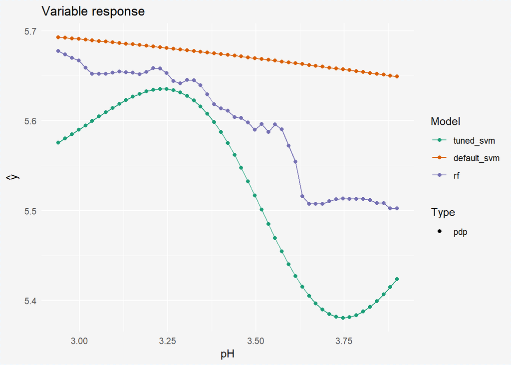

```r
plot_pH
```

Podobnie jak zmienne wyżej.

# 6 Podsumowanie

Ustaliliśmy, że normalizacja zmiennych przed dopasowaniem do SVM jest bardzo wskazana. Ponadto oczywiście parametry początkowe klasyfikacji, w tym przypadku $\gamma$ są ważne i warto znaleźć dla danego zbioru danych najlepsze, zapewne korzystając z wachlarza dostępnych funkcji, szukających optymalnych parametrów (zapewne nie z random search, a czegoś lepszego).